# AID Clase 6

Cecilia Oliva

06/05/2023

# Métodos no supervisados

## Reglas de asociación

**Ejemplo:** utilizamos el data set del repositorio UCI “AdultUCI”. R cuenta con una versión de los datos de clase transacciones para utilizar bajo el paquete arules, con el nombre “Adult”.

```r
library(arules)
data(AdultUCI)
class(AdultUCI)
```

```
## [1] "data.frame"
```

```r
str(AdultUCI)
```

```
## 'data.frame':    48842 obs. of  15 variables:
##  $ age           : int  39 50 38 53 28 37 49 52 31 42 ...
##  $ workclass     : Factor w/ 8 levels "Federal-gov",..: 7 6 4 4 4 4 4 6 4 4 ...
##  $ fnlwgt        : int  77516 83311 215646 234721 338409 284582 160187 209642 45781 159449 ...
##  $ education     : Ord.factor w/ 16 levels "Preschool"<"1st-4th"<..: 14 14 9 7 14 15 5 9 15 14 ...
##  $ education-num : int  13 13 9 7 13 14 5 9 14 13 ...
##  $ marital-status: Factor w/ 7 levels "Divorced","Married-AF-spouse",..: 5 3 1 3 3 3 4 3 5 3 ...
##  $ occupation    : Factor w/ 14 levels "Adm-clerical",..: 1 4 6 6 10 4 8 4 10 4 ...
##  $ relationship  : Factor w/ 6 levels "Husband","Not-in-family",..: 2 1 2 1 6 6 2 1 2 1 ...
##  $ race          : Factor w/ 5 levels "Amer-Indian-Eskimo",..: 5 5 5 3 3 5 3 5 5 5 ...
##  $ sex           : Factor w/ 2 levels "Female","Male": 2 2 2 2 1 1 1 2 1 2 ...
##  $ capital-gain  : int  2174 0 0 0 0 0 0 0 14084 5178 ...
##  $ capital-loss  : int  0 0 0 0 0 0 0 0 0 0 ...
##  $ hours-per-week: int  40 13 40 40 40 40 16 45 50 40 ...
##  $ native-country: Factor w/ 41 levels "Cambodia","Canada",..: 39 39 39 39 5 39 23 39 39 39 ...
##  $ income        : Ord.factor w/ 2 levels "small"<"large": 1 1 1 1 1 1 1 2 2 2 ...
```

```r
dim(AdultUCI)
```

```
## [1] 48842    15
```

El detalle de las 15 variables se pueden ver con el comando **??AdultUCI**.

**age**

a numeric vector.

**workclass**

a factor with levels Federal-gov, Local-gov, Never-worked, Private, Self-emp-inc, Self-emp-not-inc, State-gov, and Without-pay.

**education**

an ordered factor with levels Preschool < 1st-4th < 5th-6th < 7th-8th < 9th < 10th < 11th < 12th < HS-grad < Prof-school < Assoc-acdm < Assoc-voc < Some-college < Bachelors < Masters < Doctorate.

**education-num**

a numeric vector.

**marital-status**

a factor with levels Divorced, Married-AF-spouse, Married-civ-spouse, Married-spouse-absent, Never-married, Separated, and Widowed.

**occupation**

a factor with levels Adm-clerical, Armed-Forces, Craft-repair, Exec-managerial, Farming-fishing, Handlers-cleaners, Machine-op-inspct, Other-service, Priv-house-serv, Prof-specialty, Protective-serv, Sales, Tech-support, and Transport-moving.

**relationship**

a factor with levels Husband, Not-in-family, Other-relative, Own-child, Unmarried, and Wife.

**race**

a factor with levels Amer-Indian-Eskimo, Asian-Pac-Islander, Black, Other, and White.

**sex**

a factor with levels Female and Male.

**capital-gain**

a numeric vector.

**capital-loss**

a numeric vector.

**fnlwgt**

a numeric vector.

**hours-per-week**

a numeric vector.

**native-country**

a factor with levels Cambodia, Canada, China, Columbia, Cuba, Dominican-Republic, Ecuador, El-Salvador, England, France, Germany, Greece, Guatemala, Haiti, Holand-Netherlands, Honduras, Hong, Hungary, India, Iran, Ireland, Italy, Jamaica, Japan, Laos, Mexico, Nicaragua, Outlying-US(Guam-USVI-etc), Peru, Philippines, Poland, Portugal, Puerto-Rico, Scotland, South, Taiwan, Thailand, Trinadad&Tobago, United-States, Vietnam, and Yugoslavia.

**income**

an ordered factor with levels small < large.

La base de datos fue extraída de un censo de 1994 y fue originalmente utilizada para predecir si los ingresos excedían USD 50000 al año. Para obtener la base transformada “Adult” en un objeto de clase “transactions” se realizaron las siguientes operaciones:

-# remove attributes

AdultUCI[[“fnlwgt”]] <- NULL

AdultUCI[[“education-num”]] <- NULL

-# map metric attributes

AdultUCI[[“age”]] <- ordered(cut(AdultUCI[[“age”]], c(15, 25, 45, 65, 100)), labels = c(“Young”, “Middle-aged”, “Senior”, “Old”))

AdultUCI[[“hours-per-week”]] <- ordered(cut(AdultUCI[[“hours-per-week”]], c(0,25,40,60,168)), labels = c(“Part-time”, “Full-time”, “Over-time”, “Workaholic”))

AdultUCI[[“capital-gain”]] <- ordered(cut(AdultUCI[[“capital-gain”]], c(-Inf,0,median(AdultUCI[[“capital-gain”]][AdultUCI[[“capital-gain”]] > 0]), Inf)), labels = c(“None”, “Low”, “High”))

AdultUCI[[“capital-loss”]] <- ordered(cut(AdultUCI[[“capital-loss”]], c(-Inf,0, median(AdultUCI[[“capital-loss”]][AdultUCI[[“capital-loss”]] > 0]), Inf)), labels = c(“None”, “Low”, “High”))

-# create transactions

Adult <- transactions(AdultUCI)

```r
data(Adult)
class(Adult)
```

```
## [1] "transactions"
## attr(,"package")
## [1] "arules"
```

```r
str(Adult)
```

```
## Formal class 'transactions' [package "arules"] with 3 slots
##   ..@ data       :Formal class 'ngCMatrix' [package "Matrix"] with 5 slots
##   .. .. ..@ i       : int [1:612200] 1 10 25 32 35 50 59 61 63 65 ...
##   .. .. ..@ p       : int [1:48843] 0 13 26 39 52 65 78 91 104 117 ...
##   .. .. ..@ Dim     : int [1:2] 115 48842
##   .. .. ..@ Dimnames:List of 2
##   .. .. .. ..$ : NULL
##   .. .. .. ..$ : NULL
##   .. .. ..@ factors : list()
##   ..@ itemInfo   :'data.frame':  115 obs. of  3 variables:
##   .. ..$ labels   : chr [1:115] "age=Young" "age=Middle-aged" "age=Senior" "age=Old" ...
##   .. ..$ variables: Factor w/ 13 levels "age","capital-gain",..: 1 1 1 1 13 13 13 13 13 13 ...
##   .. ..$ levels   : Factor w/ 112 levels "10th","11th",..: 111 63 92 69 30 54 65 82 90 91 ...
##   ..@ itemsetInfo:'data.frame':  48842 obs. of  1 variable:
##   .. ..$ transactionID: chr [1:48842] "1" "2" "3" "4" ...
```

```r
dim(Adult)
```

```
## [1] 48842   115
```

```r
colnames(Adult)
```

```
##   [1] "age=Young"
##   [2] "age=Middle-aged"
##   [3] "age=Senior"
##   [4] "age=Old"
##   [5] "workclass=Federal-gov"
##   [6] "workclass=Local-gov"
##   [7] "workclass=Never-worked"
##   [8] "workclass=Private"
##   [9] "workclass=Self-emp-inc"
##  [10] "workclass=Self-emp-not-inc"
##  [11] "workclass=State-gov"
##  [12] "workclass=Without-pay"
##  [13] "education=Preschool"
##  [14] "education=1st-4th"
##  [15] "education=5th-6th"
```

[output cut: 100 more lines]

```r
inspect(Adult[1:5])
```

```
##     items                                transactionID
## [1] {age=Middle-aged,
##      workclass=State-gov,
##      education=Bachelors,
##      marital-status=Never-married,
##      occupation=Adm-clerical,
##      relationship=Not-in-family,
##      race=White,
##      sex=Male,
##      capital-gain=Low,
##      capital-loss=None,
##      hours-per-week=Full-time,
##      native-country=United-States,
##      income=small}                                   1
## [2] {age=Senior,
##      workclass=Self-emp-not-inc,
##      education=Bachelors,
##      marital-status=Married-civ-spouse,
##      occupation=Exec-managerial,
##      relationship=Husband,
##      race=White,
##      sex=Male,
##      capital-gain=None,
##      capital-loss=None,
##      hours-per-week=Part-time,
##      native-country=United-States,
##      income=small}                                   2
## [3] {age=Middle-aged,
##      workclass=Private,
##      education=HS-grad,
##      marital-status=Divorced,
##      occupation=Handlers-cleaners,
##      relationship=Not-in-family,
##      race=White,
##      sex=Male,
##      capital-gain=None,
##      capital-loss=None,
##      hours-per-week=Full-time,
##      native-country=United-States,
##      income=small}                                   3
```

[output cut: 11 more lines]

```
##      native-country=United-States,
##      income=small}                                   4
## [5] {age=Middle-aged,
##      workclass=Private,
##      education=Bachelors,
##      marital-status=Married-civ-spouse,
##      occupation=Prof-specialty,
##      relationship=Wife,
##      race=Black,
##      sex=Female,
##      capital-gain=None,
##      capital-loss=None,
##      hours-per-week=Full-time,
##      native-country=Cuba,
##      income=small}                                   5
```

Para que se visualice mejor:

```r
df_transac <- as(Adult, Class = "data.frame")
library(tidyverse)
as_tibble(df_transac) %>% head()
```

| items | transactionID |
| --- | --- |
| {age=Middle-aged,workclass=State-gov,education=Bachelors,marital-status=Never-married,occupation=Adm-clerical,relationship=Not-in-family,race=White,sex=Male,capital-gain=Low,capital-loss=None,hours-pe… | 1 |
| {age=Senior,workclass=Self-emp-not-inc,education=Bachelors,marital-status=Married-civ-spouse,occupation=Exec-managerial,relationship=Husband,race=White,sex=Male,capital-gain=None,capital-loss=None,hou… | 2 |
| {age=Middle-aged,workclass=Private,education=HS-grad,marital-status=Divorced,occupation=Handlers-cleaners,relationship=Not-in-family,race=White,sex=Male,capital-gain=None,capital-loss=None,hours-per-w… | 3 |
| {age=Senior,workclass=Private,education=11th,marital-status=Married-civ-spouse,occupation=Handlers-cleaners,relationship=Husband,race=Black,sex=Male,capital-gain=None,capital-loss=None,hours-per-week=… | 4 |
| {age=Middle-aged,workclass=Private,education=Bachelors,marital-status=Married-civ-spouse,occupation=Prof-specialty,relationship=Wife,race=Black,sex=Female,capital-gain=None,capital-loss=None,hours-per… | 5 |
| {age=Middle-aged,workclass=Private,education=Masters,marital-status=Married-civ-spouse,occupation=Exec-managerial,relationship=Wife,race=White,sex=Female,capital-gain=None,capital-loss=None,hours-per-… | 6 |

#### Frecuencia de items

Calculamos primero la distribución de la cantidad de items por transacción.

```r
cant_items<- size(Adult)
summary(cant_items)
```

```
##    Min. 1st Qu.  Median    Mean 3rd Qu.    Max.
##    9.00   12.00   13.00   12.53   13.00   13.00
```

Se puede calcular la frecuencia de cada ítem de forma relativa o absoluta:

```r
frecuencia_items <- itemFrequency(x = Adult, type = "relative")
frecuencia_items %>% sort(decreasing = TRUE) %>% head(5)
```

```
##            capital-loss=None            capital-gain=None
##                    0.9532779                    0.9173867
## native-country=United-States                   race=White
##                    0.8974243                    0.8550428
##            workclass=Private
##                    0.6941976
```

```r
frecuencia_items <- itemFrequency(x = Adult, type = "absolute")
frecuencia_items %>% sort(decreasing = TRUE) %>% head(5)
```

```
##            capital-loss=None            capital-gain=None
##                        46560                        44807
## native-country=United-States                   race=White
##                        43832                        41762
##            workclass=Private
##                        33906
```

#### Frecuencia de itemsets

Si no se aclara el valor del soporte dentro del argumento parameter, se toma por default un soporte de 0.1 para considerarlo un itemset frecuente.

```r
itemsets <- apriori(data = Adult, parameter = list( minlen = 9, maxlen = 13,target = "frequent itemset"))
```

```
## Apriori
##
## Parameter specification:
##  confidence minval smax arem  aval originalSupport maxtime support minlen
##          NA    0.1    1 none FALSE            TRUE       5     0.1      9
##  maxlen            target  ext
##      13 frequent itemsets TRUE
##
## Algorithmic control:
##  filter tree heap memopt load sort verbose
##     0.1 TRUE TRUE  FALSE TRUE    2    TRUE
##
## Absolute minimum support count: 4884
##
## set item appearances ...[0 item(s)] done [0.00s].
## set transactions ...[115 item(s), 48842 transaction(s)] done [0.04s].
## sorting and recoding items ... [31 item(s)] done [0.01s].
## creating transaction tree ... done [0.03s].
## checking subsets of size 1 2 3 4 5 6 7 8 9 done [0.09s].
## sorting transactions ... done [0.01s].
## writing ... [1 set(s)] done [0.00s].
## creating S4 object  ... done [0.00s].
```

```r
summary(itemsets)
```

```
## set of 1 itemsets
##
## most frequent items:
##                   age=Middle-aged                 workclass=Private
##                                 1                                 1
## marital-status=Married-civ-spouse              relationship=Husband
##                                 1                                 1
##                        race=White                           (Other)
##                                 1                                 4
##
## element (itemset/transaction) length distribution:sizes
## 9
## 1
##
##    Min. 1st Qu.  Median    Mean 3rd Qu.    Max.
##       9       9       9       9       9       9
##
## summary of quality measures:
##     support           count
##  Min.   :0.1057   Min.   :5161
##  1st Qu.:0.1057   1st Qu.:5161
##  Median :0.1057   Median :5161
##  Mean   :0.1057   Mean   :5161
##  3rd Qu.:0.1057   3rd Qu.:5161
##  Max.   :0.1057   Max.   :5161
##
## includes transaction ID lists: FALSE
##
## mining info:
##   data ntransactions support confidence
##  Adult         48842     0.1          1
##                                                                                           call
##  apriori(data = Adult, parameter = list(minlen = 9, maxlen = 13, target = "frequent itemset"))
```

```r
inspect(itemsets)
```

```
##     items                                  support count
## [1] {age=Middle-aged,
##      workclass=Private,
##      marital-status=Married-civ-spouse,
##      relationship=Husband,
##      race=White,
##      sex=Male,
##      capital-gain=None,
##      capital-loss=None,
##      native-country=United-States}       0.1056673  5161
```

```r
itemsets_2 <- apriori(data = Adult, parameter = list( minlen = 4, maxlen = 13,target = "frequent itemset"))
```

```
## Apriori
##
## Parameter specification:
##  confidence minval smax arem  aval originalSupport maxtime support minlen
##          NA    0.1    1 none FALSE            TRUE       5     0.1      4
##  maxlen            target  ext
##      13 frequent itemsets TRUE
##
## Algorithmic control:
##  filter tree heap memopt load sort verbose
##     0.1 TRUE TRUE  FALSE TRUE    2    TRUE
##
## Absolute minimum support count: 4884
##
## set item appearances ...[0 item(s)] done [0.00s].
## set transactions ...[115 item(s), 48842 transaction(s)] done [0.03s].
## sorting and recoding items ... [31 item(s)] done [0.01s].
## creating transaction tree ... done [0.02s].
## checking subsets of size 1 2 3 4 5 6 7 8 9 done [0.08s].
## sorting transactions ... done [0.01s].
## writing ... [1896 set(s)] done [0.00s].
## creating S4 object  ... done [0.00s].
```

```r
summary(itemsets_2)
```

```
## set of 1896 itemsets
##
## most frequent items:
##            capital-loss=None            capital-gain=None
##                         1076                         1053
## native-country=United-States                   race=White
##                         1044                         1005
##                     sex=Male                      (Other)
##                          809                         4348
##
## element (itemset/transaction) length distribution:sizes
##   4   5   6   7   8   9
## 757 666 352 104  16   1
##
##    Min. 1st Qu.  Median    Mean 3rd Qu.    Max.
##   4.000   4.000   5.000   4.924   5.000   9.000
##
## summary of quality measures:
##     support           count
##  Min.   :0.1000   Min.   : 4885
##  1st Qu.:0.1155   1st Qu.: 5641
##  Median :0.1333   Median : 6510
##  Mean   :0.1580   Mean   : 7716
##  3rd Qu.:0.1802   3rd Qu.: 8803
##  Max.   :0.6804   Max.   :33232
##
## includes transaction ID lists: FALSE
##
## mining info:
##   data ntransactions support confidence
##  Adult         48842     0.1          1
##                                                                                           call
##  apriori(data = Adult, parameter = list(minlen = 4, maxlen = 13, target = "frequent itemset"))
```

```r
DiezDeMayorSoporte<-sort(itemsets_2, by = "support", decreasing = TRUE)[1:10]
inspect(DiezDeMayorSoporte)
```

```
##      items                            support count
## [1]  {race=White,
##       capital-gain=None,
##       capital-loss=None,
##       native-country=United-States} 0.6803980 33232
## [2]  {workclass=Private,
##       capital-gain=None,
##       capital-loss=None,
##       native-country=United-States} 0.5414807 26447
## [3]  {workclass=Private,
##       race=White,
##       capital-gain=None,
##       capital-loss=None}            0.5204742 25421
## [4]  {workclass=Private,
##       race=White,
##       capital-loss=None,
##       native-country=United-States} 0.5181401 25307
## [5]  {race=White,
##       sex=Male,
##       capital-loss=None,
##       native-country=United-States} 0.5113632 24976
## [6]  {sex=Male,
##       capital-gain=None,
##       capital-loss=None,
##       native-country=United-States} 0.5084149 24832
## [7]  {race=White,
##       sex=Male,
##       capital-gain=None,
##       capital-loss=None}            0.4994062 24392
## [8]  {workclass=Private,
##       race=White,
##       capital-gain=None,
##       native-country=United-States} 0.4994062 24392
## [9]  {race=White,
##       sex=Male,
##       capital-gain=None,
##       native-country=United-States} 0.4881045 23840
## [10] {workclass=Private,
##       race=White,
##       capital-gain=None,
##       capital-loss=None,
##       native-country=United-States} 0.4741616 23159
```

```r
itemsets_3 <- apriori(data = Adult, parameter = list( minlen = 6, maxlen = 13,target = "frequent itemset"))
```

```
## Apriori
##
## Parameter specification:
##  confidence minval smax arem  aval originalSupport maxtime support minlen
##          NA    0.1    1 none FALSE            TRUE       5     0.1      6
##  maxlen            target  ext
##      13 frequent itemsets TRUE
##
## Algorithmic control:
##  filter tree heap memopt load sort verbose
##     0.1 TRUE TRUE  FALSE TRUE    2    TRUE
##
## Absolute minimum support count: 4884
##
## set item appearances ...[0 item(s)] done [0.00s].
## set transactions ...[115 item(s), 48842 transaction(s)] done [0.03s].
## sorting and recoding items ... [31 item(s)] done [0.01s].
## creating transaction tree ... done [0.02s].
## checking subsets of size 1 2 3 4 5 6 7 8 9 done [0.08s].
## sorting transactions ... done [0.01s].
## writing ... [473 set(s)] done [0.00s].
## creating S4 object  ... done [0.00s].
```

```r
summary(itemsets_3)
```

```
## set of 473 itemsets
##
## most frequent items:
##            capital-loss=None            capital-gain=None
##                          350                          347
## native-country=United-States                   race=White
##                          346                          340
##                     sex=Male                      (Other)
##                          299                         1295
##
## element (itemset/transaction) length distribution:sizes
##   6   7   8   9
## 352 104  16   1
##
##    Min. 1st Qu.  Median    Mean 3rd Qu.    Max.
##   6.000   6.000   6.000   6.294   7.000   9.000
##
## summary of quality measures:
##     support           count
##  Min.   :0.1003   Min.   : 4901
##  1st Qu.:0.1092   1st Qu.: 5332
##  Median :0.1211   Median : 5913
##  Mean   :0.1355   Mean   : 6619
##  3rd Qu.:0.1528   3rd Qu.: 7462
##  Max.   :0.3159   Max.   :15431
##
## includes transaction ID lists: FALSE
##
## mining info:
##   data ntransactions support confidence
##  Adult         48842     0.1          1
##                                                                                           call
##  apriori(data = Adult, parameter = list(minlen = 6, maxlen = 13, target = "frequent itemset"))
```

```r
DiezDeMayorSoporte_3<-sort(itemsets_3, by = "support", decreasing = TRUE)[1:10]
inspect(DiezDeMayorSoporte_3)
```

```
##      items                                  support count
## [1]  {marital-status=Married-civ-spouse,
##       relationship=Husband,
##       race=White,
##       sex=Male,
##       capital-loss=None,
##       native-country=United-States}       0.3159371 15431
## [2]  {workclass=Private,
##       race=White,
##       sex=Male,
##       capital-gain=None,
##       capital-loss=None,
##       native-country=United-States}       0.3121084 15244
## [3]  {marital-status=Married-civ-spouse,
##       relationship=Husband,
##       race=White,
##       sex=Male,
##       capital-gain=None,
##       capital-loss=None}                  0.2975513 14533
## [4]  {marital-status=Married-civ-spouse,
##       relationship=Husband,
##       race=White,
##       sex=Male,
##       capital-gain=None,
##       native-country=United-States}       0.2967528 14494
## [5]  {marital-status=Married-civ-spouse,
##       relationship=Husband,
##       sex=Male,
##       capital-gain=None,
##       capital-loss=None,
##       native-country=United-States}       0.2953196 14424
## [6]  {workclass=Private,
##       race=White,
##       capital-gain=None,
##       capital-loss=None,
##       hours-per-week=Full-time,
##       native-country=United-States}       0.2808444 13717
## [7]  {marital-status=Married-civ-spouse,
##       race=White,
##       sex=Male,
##       capital-gain=None,
##       capital-loss=None,
##       native-country=United-States}       0.2765243 13506
## [8]  {relationship=Husband,
##       race=White,
##       sex=Male,
##       capital-gain=None,
##       capital-loss=None,
##       native-country=United-States}       0.2746407 13414
## [9]  {marital-status=Married-civ-spouse,
##       relationship=Husband,
##       race=White,
##       capital-gain=None,
##       capital-loss=None,
##       native-country=United-States}       0.2744769 13406
## [10] {marital-status=Married-civ-spouse,
##       relationship=Husband,
##       race=White,
##       sex=Male,
##       capital-gain=None,
##       capital-loss=None,
##       native-country=United-States}       0.2744564 13405
```

#### Filtrado de items

```r
itemsets_workPriv <- arules::subset(itemsets_3, subset = items %in% "workclass=Private")
itemsets_workPriv
```

```
## set of 249 itemsets
```

```r
itemsets_workPriv_10<-sort(itemsets_workPriv, by = "support", decreasing = TRUE)[1:10]
inspect(itemsets_workPriv_10)
```

```
##      items                                  support count
## [1]  {workclass=Private,
##       race=White,
##       sex=Male,
##       capital-gain=None,
##       capital-loss=None,
##       native-country=United-States}       0.3121084 15244
## [2]  {workclass=Private,
##       race=White,
##       capital-gain=None,
##       capital-loss=None,
##       hours-per-week=Full-time,
##       native-country=United-States}       0.2808444 13717
## [3]  {workclass=Private,
##       race=White,
##       capital-gain=None,
##       capital-loss=None,
##       native-country=United-States,
##       income=small}                       0.2555997 12484
## [4]  {age=Middle-aged,
##       workclass=Private,
##       race=White,
##       capital-gain=None,
##       capital-loss=None,
##       native-country=United-States}       0.2427419 11856
## [5]  {workclass=Private,
##       marital-status=Married-civ-spouse,
##       relationship=Husband,
##       race=White,
##       sex=Male,
##       capital-loss=None}                  0.2212645 10807
## [6]  {workclass=Private,
##       marital-status=Married-civ-spouse,
##       relationship=Husband,
##       sex=Male,
##       capital-loss=None,
##       native-country=United-States}       0.2177429 10635
## [7]  {workclass=Private,
##       marital-status=Married-civ-spouse,
##       relationship=Husband,
##       race=White,
##       sex=Male,
##       native-country=United-States}       0.2164735 10573
## [8]  {workclass=Private,
##       marital-status=Married-civ-spouse,
##       relationship=Husband,
##       sex=Male,
##       capital-gain=None,
##       capital-loss=None}                  0.2149584 10499
## [9]  {workclass=Private,
##       marital-status=Married-civ-spouse,
##       relationship=Husband,
##       race=White,
##       sex=Male,
##       capital-gain=None}                  0.2085091 10184
## [10] {workclass=Private,
##       marital-status=Married-civ-spouse,
##       relationship=Husband,
##       sex=Male,
##       capital-gain=None,
##       native-country=United-States}       0.2052332 10024
```

```r
itemsets_workPriv_full <- arules::subset(itemsets, subset = items %ain% c("workclass=Private", "hours-per-week=Full-time"))
itemsets_workPriv_full
```

```
## set of 0 itemsets
```

```r
itemsets_workPriv_male <- arules::subset(itemsets, subset = items %ain% c("workclass=Private", "sex=Male"))
itemsets_workPriv_male
```

```
## set of 1 itemsets
```

```r
inspect(itemsets_workPriv_male)
```

```
##     items                                  support count
## [1] {age=Middle-aged,
##      workclass=Private,
##      marital-status=Married-civ-spouse,
##      relationship=Husband,
##      race=White,
##      sex=Male,
##      capital-gain=None,
##      capital-loss=None,
##      native-country=United-States}       0.1056673  5161
```

#### Generación de reglas

```r
soporte <- 24421/dim(Adult)[1]# 50%
reglas <- apriori(data = Adult, parameter = list(support = soporte, minlen = 2, maxlen = 13, confidence = 0.70,target = "rules"))
```

```
## Apriori
##
## Parameter specification:
##  confidence minval smax arem  aval originalSupport maxtime support minlen
##         0.7    0.1    1 none FALSE            TRUE       5     0.5      2
##  maxlen target  ext
##      13  rules TRUE
##
## Algorithmic control:
##  filter tree heap memopt load sort verbose
##     0.1 TRUE TRUE  FALSE TRUE    2    TRUE
##
## Absolute minimum support count: 24421
##
## set item appearances ...[0 item(s)] done [0.00s].
## set transactions ...[115 item(s), 48842 transaction(s)] done [0.04s].
## sorting and recoding items ... [9 item(s)] done [0.00s].
## creating transaction tree ... done [0.02s].
## checking subsets of size 1 2 3 4 done [0.00s].
## writing ... [82 rule(s)] done [0.00s].
## creating S4 object  ... done [0.00s].
```

```r
summary(reglas)
```

```
## set of 82 rules
##
## rule length distribution (lhs + rhs):sizes
##  2  3  4
## 23 39 20
##
##    Min. 1st Qu.  Median    Mean 3rd Qu.    Max.
##   2.000   2.000   3.000   2.963   3.000   4.000
##
## summary of quality measures:
##     support         confidence        coverage           lift
##  Min.   :0.5084   Min.   :0.7020   Min.   :0.5406   Min.   :0.9789
##  1st Qu.:0.5415   1st Qu.:0.8874   1st Qu.:0.5908   1st Qu.:0.9940
##  Median :0.5790   Median :0.9130   Median :0.6527   Median :0.9984
##  Mean   :0.6287   Mean   :0.9061   Mean   :0.6952   Mean   :1.0038
##  3rd Qu.:0.7352   3rd Qu.:0.9413   3rd Qu.:0.8073   3rd Qu.:1.0122
##  Max.   :0.8707   Max.   :0.9583   Max.   :0.9533   Max.   :1.0586
##      count
##  Min.   :24832
##  1st Qu.:26447
##  Median :28280
##  Mean   :30705
##  3rd Qu.:35908
##  Max.   :42525
##
## mining info:
##   data ntransactions support confidence
##  Adult         48842     0.5        0.7
##                                                                                                                     call
##  apriori(data = Adult, parameter = list(support = soporte, minlen = 2, maxlen = 13, confidence = 0.7, target = "rules"))
```

```r
inspect(sort(x = reglas, decreasing = TRUE, by = "confidence"))
```

```
##      lhs                               rhs                              support confidence  coverage      lift count
## [1]  {hours-per-week=Full-time}     => {capital-loss=None}            0.5606650  0.9582531 0.5850907 1.0052191 27384
## [2]  {workclass=Private}            => {capital-loss=None}            0.6639982  0.9564974 0.6941976 1.0033773 32431
## [3]  {workclass=Private,
##       native-country=United-States} => {capital-loss=None}            0.5897179  0.9554818 0.6171942 1.0023119 28803
## [4]  {capital-gain=None,
##       hours-per-week=Full-time}     => {capital-loss=None}            0.5191638  0.9550659 0.5435895 1.0018756 25357
## [5]  {workclass=Private,
##       race=White}                   => {capital-loss=None}            0.5674829  0.9549683 0.5942427 1.0017732 27717
## [6]  {workclass=Private,
##       race=White,
##       native-country=United-States} => {capital-loss=None}            0.5181401  0.9535418 0.5433848 1.0002768 25307
## [7]  {workclass=Private,
##       capital-gain=None}            => {capital-loss=None}            0.6111748  0.9529145 0.6413742 0.9996188 29851
## [8]  {native-country=United-States} => {capital-loss=None}            0.8548380  0.9525461 0.8974243 0.9992323 41752
## [9]  {workclass=Private,
##       capital-gain=None,
##       native-country=United-States} => {capital-loss=None}            0.5414807  0.9517075 0.5689570 0.9983526 26447
## [10] {race=White}                   => {capital-loss=None}            0.8136849  0.9516307 0.8550428 0.9982720 39742
## [11] {workclass=Private,
##       race=White,
##       capital-gain=None}            => {capital-loss=None}            0.5204742  0.9511000 0.5472339 0.9977153 25421
## [12] {race=White,
##       native-country=United-States} => {capital-loss=None}            0.7490480  0.9504325 0.7881127 0.9970152 36585
## [13] {capital-gain=None}            => {capital-loss=None}            0.8706646  0.9490705 0.9173867 0.9955863 42525
## [14] {capital-gain=None,
##       native-country=United-States} => {capital-loss=None}            0.7793702  0.9481891 0.8219565 0.9946618 38066
## [15] {race=White,
##       capital-gain=None}            => {capital-loss=None}            0.7404283  0.9470983 0.7817862 0.9935175 36164
## [16] {sex=Male}                     => {capital-loss=None}            0.6331027  0.9470750 0.6684820 0.9934931 30922
## [17] {sex=Male,
##       native-country=United-States} => {capital-loss=None}            0.5661316  0.9462068 0.5983170 0.9925823 27651
## [18] {race=White,
##       sex=Male}                     => {capital-loss=None}            0.5564268  0.9457804 0.5883256 0.9921350 27177
## [19] {race=White,
##       capital-gain=None,
##       native-country=United-States} => {capital-loss=None}            0.6803980  0.9457029 0.7194628 0.9920537 33232
## [20] {race=White,
##       sex=Male,
##       native-country=United-States} => {capital-loss=None}            0.5113632  0.9442722 0.5415421 0.9905529 24976
```

[output cut: 107 more lines]

```
##       capital-loss=None}            => {race=White}                   0.5674829  0.8546452 0.6639982 0.9995351 27717
## [76] {capital-loss=None}            => {race=White}                   0.8136849  0.8535653 0.9532779 0.9982720 39742
## [77] {workclass=Private,
##       capital-gain=None}            => {race=White}                   0.5472339  0.8532210 0.6413742 0.9978693 26728
## [78] {capital-gain=None}            => {race=White}                   0.7817862  0.8521883 0.9173867 0.9966616 38184
## [79] {workclass=Private,
##       capital-gain=None,
##       capital-loss=None}            => {race=White}                   0.5204742  0.8515963 0.6111748 0.9959692 25421
## [80] {capital-gain=None,
##       capital-loss=None}            => {race=White}                   0.7404283  0.8504174 0.8706646 0.9945905 36164
## [81] {race=White,
##       capital-gain=None,
##       capital-loss=None}            => {workclass=Private}            0.5204742  0.7029366 0.7404283 1.0125886 25421
## [82] {capital-gain=None,
##       capital-loss=None}            => {workclass=Private}            0.6111748  0.7019636 0.8706646 1.0111869 29851
```

```r
inspect(sort(x = reglas, decreasing = TRUE, by = "lift"))
```

```
##      lhs                               rhs                              support confidence  coverage      lift count
## [1]  {sex=Male,
##       native-country=United-States} => {race=White}                   0.5415421  0.9051090 0.5983170 1.0585540 26450
## [2]  {sex=Male,
##       capital-loss=None,
##       native-country=United-States} => {race=White}                   0.5113632  0.9032585 0.5661316 1.0563898 24976
## [3]  {workclass=Private,
##       native-country=United-States} => {race=White}                   0.5433848  0.8804113 0.6171942 1.0296693 26540
## [4]  {sex=Male}                     => {race=White}                   0.5883256  0.8800919 0.6684820 1.0292957 28735
## [5]  {sex=Male,
##       capital-loss=None}            => {race=White}                   0.5564268  0.8788888 0.6331027 1.0278887 27177
## [6]  {workclass=Private,
##       capital-loss=None,
##       native-country=United-States} => {race=White}                   0.5181401  0.8786238 0.5897179 1.0275787 25307
## [7]  {race=White}                   => {native-country=United-States} 0.7881127  0.9217231 0.8550428 1.0270761 38493
## [8]  {native-country=United-States} => {race=White}                   0.7881127  0.8781940 0.8974243 1.0270761 38493
## [9]  {sex=Male,
##       capital-gain=None}            => {race=White}                   0.5313050  0.8780834 0.6050735 1.0269468 25950
## [10] {race=White,
##       capital-loss=None}            => {native-country=United-States} 0.7490480  0.9205626 0.8136849 1.0257830 36585
## [11] {race=White,
##       sex=Male}                     => {native-country=United-States} 0.5415421  0.9204803 0.5883256 1.0256912 26450
## [12] {race=White,
##       capital-gain=None}            => {native-country=United-States} 0.7194628  0.9202807 0.7817862 1.0254689 35140
## [13] {capital-loss=None,
##       native-country=United-States} => {race=White}                   0.7490480  0.8762454 0.8548380 1.0247972 36585
## [14] {race=White,
##       sex=Male,
##       capital-loss=None}            => {native-country=United-States} 0.5113632  0.9190124 0.5564268 1.0240556 24976
## [15] {race=White,
##       capital-gain=None,
##       capital-loss=None}            => {native-country=United-States} 0.6803980  0.9189249 0.7404283 1.0239581 33232
## [16] {capital-gain=None,
##       native-country=United-States} => {race=White}                   0.7194628  0.8753051 0.8219565 1.0236975 35140
## [17] {capital-gain=None,
##       capital-loss=None,
##       native-country=United-States} => {race=White}                   0.6803980  0.8730100 0.7793702 1.0210133 33232
## [18] {workclass=Private,
##       race=White}                   => {native-country=United-States} 0.5433848  0.9144157 0.5942427 1.0189334 26540
## [19] {workclass=Private,
```

[output cut: 107 more lines]

```
##       capital-loss=None}            => {native-country=United-States} 0.5414807  0.8859670 0.6111748 0.9872330 26447
## [76] {sex=Male}                     => {capital-gain=None}            0.6050735  0.9051455 0.6684820 0.9866565 29553
## [77] {sex=Male,
##       capital-gain=None,
##       native-country=United-States} => {capital-loss=None}            0.5084149  0.9404636 0.5406003 0.9865576 24832
## [78] {hours-per-week=Full-time}     => {native-country=United-States} 0.5179559  0.8852574 0.5850907 0.9864423 25298
## [79] {sex=Male,
##       native-country=United-States} => {capital-gain=None}            0.5406003  0.9035349 0.5983170 0.9849008 26404
## [80] {race=White,
##       sex=Male}                     => {capital-gain=None}            0.5313050  0.9030799 0.5883256 0.9844048 25950
## [81] {sex=Male,
##       capital-loss=None}            => {capital-gain=None}            0.5696941  0.8998448 0.6331027 0.9808784 27825
## [82] {sex=Male,
##       capital-loss=None,
##       native-country=United-States} => {capital-gain=None}            0.5084149  0.8980507 0.5661316 0.9789228 24832
```

#### Algunas métricas de evaluación de reglas

```r
metricas <- interestMeasure(reglas, measure = c("lift","coverage", "fishersExactTest"), transactions = Adult)
metricas
```

| lift | coverage | fishersExactTest |
| --- | --- | --- |
| 0.9864423 | 0.5850907 | 1.000000e+00 |
| 1.0127342 | 0.5850907 | 1.121041e-28 |
| 1.0052191 | 0.5850907 | 4.345302e-10 |
| 1.0292957 | 0.6684820 | 1.443330e-106 |
| 0.9973412 | 0.6684820 | 9.936385e-01 |
| 0.9866565 | 0.6684820 | 1.000000e+00 |
| 0.9934931 | 0.6684820 | 1.000000e+00 |
| 1.0011355 | 0.6941976 | 1.828473e-01 |
| 0.9906971 | 0.6941976 | 1.000000e+00 |
| 1.0071078 | 0.6941976 | 4.115642e-15 |

[output cut: 72 more lines]

```r
#para ver más métricas consultar:?interestMeasure

quality(reglas)
```

|  | support | confidence | coverage | lift | count |
| --- | --- | --- | --- | --- | --- |
| 1 | 0.5179559 | 0.8852574 | 0.5850907 | 0.9864423 | 25298 |
| 2 | 0.5435895 | 0.9290688 | 0.5850907 | 1.0127342 | 26550 |
| 3 | 0.5606650 | 0.9582531 | 0.5850907 | 1.0052191 | 27384 |
| 4 | 0.5883256 | 0.8800919 | 0.6684820 | 1.0292957 | 28735 |
| 5 | 0.5983170 | 0.8950383 | 0.6684820 | 0.9973412 | 29223 |
| 6 | 0.6050735 | 0.9051455 | 0.6684820 | 0.9866565 | 29553 |
| 7 | 0.6331027 | 0.9470750 | 0.6684820 | 0.9934931 | 30922 |
| 8 | 0.5942427 | 0.8560137 | 0.6941976 | 1.0011355 | 29024 |
| 9 | 0.6171942 | 0.8890757 | 0.6941976 | 0.9906971 | 30145 |
| 10 | 0.6413742 | 0.9239073 | 0.6941976 | 1.0071078 | 31326 |

[output cut: 72 more lines]

#### Reglas con un determinado consecuente (rhs)

```r
soporte <- 100 / dim(Adult)[1]
reglas_2 <- apriori(data = Adult, parameter = list(support = soporte, minlen = 2, maxlen = 13, confidence = 0.70,target = "rules"), appearance = list(rhs = "income=large"))
```

```
## Apriori
##
## Parameter specification:
##  confidence minval smax arem  aval originalSupport maxtime     support minlen
##         0.7    0.1    1 none FALSE            TRUE       5 0.002047418      2
##  maxlen target  ext
##      13  rules TRUE
##
## Algorithmic control:
##  filter tree heap memopt load sort verbose
##     0.1 TRUE TRUE  FALSE TRUE    2    TRUE
##
## Absolute minimum support count: 99
##
## set item appearances ...[1 item(s)] done [0.00s].
## set transactions ...[115 item(s), 48842 transaction(s)] done [0.04s].
## sorting and recoding items ... [84 item(s)] done [0.01s].
## creating transaction tree ... done [0.02s].
## checking subsets of size 1 2 3 4 5 6 7 8 9 10 11 12 13 done [1.40s].
## writing ... [396 rule(s)] done [0.02s].
## creating S4 object  ... done [0.02s].
```

```r
summary(reglas_2)#set of 396 rules
```

```
## set of 396 rules
##
## rule length distribution (lhs + rhs):sizes
##   3   4   5   6   7   8   9  10
##   1  10  51 115 123  69  23   4
##
##    Min. 1st Qu.  Median    Mean 3rd Qu.    Max.
##   3.000   6.000   7.000   6.687   7.000  10.000
##
## summary of quality measures:
##     support           confidence        coverage             lift
##  Min.   :0.002047   Min.   :0.7000   Min.   :0.002846   Min.   :4.360
##  1st Qu.:0.002314   1st Qu.:0.7040   1st Qu.:0.003194   1st Qu.:4.385
##  Median :0.002559   Median :0.7088   Median :0.003603   Median :4.415
##  Mean   :0.002871   Mean   :0.7118   Mean   :0.004035   Mean   :4.434
##  3rd Qu.:0.003214   3rd Qu.:0.7174   3rd Qu.:0.004566   3rd Qu.:4.469
##  Max.   :0.005569   Max.   :0.7468   Max.   :0.007842   Max.   :4.652
##      count
##  Min.   :100.0
##  1st Qu.:113.0
##  Median :125.0
##  Mean   :140.2
##  3rd Qu.:157.0
##  Max.   :272.0
##
## mining info:
##   data ntransactions     support confidence
##  Adult         48842 0.002047418        0.7
##                                                                                                                                                              call
##  apriori(data = Adult, parameter = list(support = soporte, minlen = 2, maxlen = 13, confidence = 0.7, target = "rules"), appearance = list(rhs = "income=large"))
```

Observamos las 10 primeras reglas más confiables:

```r
inspect(sort(x = reglas_2, decreasing = TRUE, by = "confidence")[1:10])
```

```
##      lhs                                     rhs                support confidence    coverage     lift count
## [1]  {age=Middle-aged,
##       workclass=Private,
##       occupation=Exec-managerial,
##       race=White,
##       capital-gain=High,
##       native-country=United-States}       => {income=large} 0.002354531  0.7467532 0.003153024 4.651565   115
## [2]  {age=Middle-aged,
##       workclass=Private,
##       occupation=Exec-managerial,
##       race=White,
##       capital-gain=High,
##       capital-loss=None,
##       native-country=United-States}       => {income=large} 0.002354531  0.7467532 0.003153024 4.651565   115
## [3]  {age=Middle-aged,
##       workclass=Private,
##       occupation=Exec-managerial,
##       race=White,
##       capital-gain=High}                  => {income=large} 0.002436428  0.7391304 0.003296343 4.604082   119
## [4]  {age=Middle-aged,
##       workclass=Private,
##       occupation=Exec-managerial,
##       race=White,
##       capital-gain=High,
##       capital-loss=None}                  => {income=large} 0.002436428  0.7391304 0.003296343 4.604082   119
## [5]  {age=Middle-aged,
##       workclass=Private,
##       occupation=Prof-specialty,
##       race=White,
##       capital-gain=High,
##       native-country=United-States}       => {income=large} 0.002088367  0.7338129 0.002845911 4.570959   102
## [6]  {age=Middle-aged,
##       workclass=Private,
##       occupation=Prof-specialty,
##       race=White,
##       capital-gain=High,
##       capital-loss=None,
##       native-country=United-States}       => {income=large} 0.002088367  0.7338129 0.002845911 4.570959   102
## [7]  {marital-status=Married-civ-spouse,
##       occupation=Exec-managerial,
##       race=White,
##       sex=Male,
##       capital-gain=High,
##       hours-per-week=Over-time}           => {income=large} 0.002927808  0.7333333 0.003992466 4.567972   143
## [8]  {marital-status=Married-civ-spouse,
##       occupation=Exec-managerial,
##       race=White,
##       sex=Male,
##       capital-gain=High,
##       capital-loss=None,
##       hours-per-week=Over-time}           => {income=large} 0.002927808  0.7333333 0.003992466 4.567972   143
## [9]  {occupation=Exec-managerial,
##       relationship=Husband,
##       race=White,
##       capital-gain=High,
##       hours-per-week=Over-time}           => {income=large} 0.002907334  0.7319588 0.003971991 4.559410   142
## [10] {marital-status=Married-civ-spouse,
##       occupation=Exec-managerial,
##       relationship=Husband,
##       race=White,
##       capital-gain=High,
##       hours-per-week=Over-time}           => {income=large} 0.002907334  0.7319588 0.003971991 4.559410   142
```

#### Restricción de reglas redundantes

```r
reglas_2_a <- reglas_2[is.redundant(x = reglas_2, measure = "confidence")]
reglas_2_a#set of 312 rules
```

```
## set of 312 rules
```

```r
summary(reglas_2_a)
```

```
## set of 312 rules
##
## rule length distribution (lhs + rhs):sizes
##   4   5   6   7   8   9  10
##   1  20  83 113  68  23   4
##
##    Min. 1st Qu.  Median    Mean 3rd Qu.    Max.
##       4       6       7       7       8      10
##
## summary of quality measures:
##     support           confidence        coverage             lift
##  Min.   :0.002047   Min.   :0.7000   Min.   :0.002846   Min.   :4.360
##  1st Qu.:0.002293   1st Qu.:0.7040   1st Qu.:0.003184   1st Qu.:4.385
##  Median :0.002518   Median :0.7081   Median :0.003563   Median :4.411
##  Mean   :0.002851   Mean   :0.7113   Mean   :0.004011   Mean   :4.430
##  3rd Qu.:0.003158   3rd Qu.:0.7155   3rd Qu.:0.004458   3rd Qu.:4.457
##  Max.   :0.005569   Max.   :0.7468   Max.   :0.007842   Max.   :4.652
##      count
##  Min.   :100.0
##  1st Qu.:112.0
##  Median :123.0
##  Mean   :139.3
##  3rd Qu.:154.2
##  Max.   :272.0
##
## mining info:
##   data ntransactions     support confidence
##  Adult         48842 0.002047418        0.7
##                                                                                                                                                              call
##  apriori(data = Adult, parameter = list(support = soporte, minlen = 2, maxlen = 13, confidence = 0.7, target = "rules"), appearance = list(rhs = "income=large"))
```

A continuación se muestran las 10 reglas de mayor confianza.

```r
inspect(sort(x = reglas_2_a, decreasing = TRUE, by = "confidence")[1:10])
```

```
##      lhs                                     rhs                support confidence    coverage     lift count
## [1]  {age=Middle-aged,
##       workclass=Private,
##       occupation=Exec-managerial,
##       race=White,
##       capital-gain=High,
##       capital-loss=None,
##       native-country=United-States}       => {income=large} 0.002354531  0.7467532 0.003153024 4.651565   115
## [2]  {age=Middle-aged,
##       workclass=Private,
##       occupation=Exec-managerial,
##       race=White,
##       capital-gain=High,
##       capital-loss=None}                  => {income=large} 0.002436428  0.7391304 0.003296343 4.604082   119
## [3]  {age=Middle-aged,
##       workclass=Private,
##       occupation=Prof-specialty,
##       race=White,
##       capital-gain=High,
##       capital-loss=None,
##       native-country=United-States}       => {income=large} 0.002088367  0.7338129 0.002845911 4.570959   102
## [4]  {marital-status=Married-civ-spouse,
##       occupation=Exec-managerial,
##       race=White,
##       sex=Male,
##       capital-gain=High,
##       capital-loss=None,
##       hours-per-week=Over-time}           => {income=large} 0.002927808  0.7333333 0.003992466 4.567972   143
## [5]  {marital-status=Married-civ-spouse,
##       occupation=Exec-managerial,
##       relationship=Husband,
##       race=White,
##       capital-gain=High,
##       hours-per-week=Over-time}           => {income=large} 0.002907334  0.7319588 0.003971991 4.559410   142
## [6]  {occupation=Exec-managerial,
##       relationship=Husband,
##       race=White,
##       sex=Male,
##       capital-gain=High,
##       hours-per-week=Over-time}           => {income=large} 0.002907334  0.7319588 0.003971991 4.559410   142
```

[output cut: 12 more lines]

```
##       hours-per-week=Over-time}           => {income=large} 0.002907334  0.7319588 0.003971991 4.559410   142
## [9]  {marital-status=Married-civ-spouse,
##       occupation=Exec-managerial,
##       relationship=Husband,
##       race=White,
##       capital-gain=High,
##       capital-loss=None,
##       hours-per-week=Over-time}           => {income=large} 0.002907334  0.7319588 0.003971991 4.559410   142
## [10] {occupation=Exec-managerial,
##       relationship=Husband,
##       race=White,
##       sex=Male,
##       capital-gain=High,
##       capital-loss=None,
##       hours-per-week=Over-time}           => {income=large} 0.002907334  0.7319588 0.003971991 4.559410   142
```

```r
# otra forma de obtenerlo
as(reglas_2_a, "data.frame") %>% arrange(desc(confidence)) %>% head(10) %>% pull(rules)
```

```
##  [1] "{age=Middle-aged,workclass=Private,occupation=Exec-managerial,race=White,capital-gain=High,capital-loss=None,native-country=United-States} => {income=large}"
##  [2] "{age=Middle-aged,workclass=Private,occupation=Exec-managerial,race=White,capital-gain=High,capital-loss=None} => {income=large}"
##  [3] "{age=Middle-aged,workclass=Private,occupation=Prof-specialty,race=White,capital-gain=High,capital-loss=None,native-country=United-States} => {income=large}"
##  [4] "{marital-status=Married-civ-spouse,occupation=Exec-managerial,race=White,sex=Male,capital-gain=High,capital-loss=None,hours-per-week=Over-time} => {income=large}"
##  [5] "{marital-status=Married-civ-spouse,occupation=Exec-managerial,relationship=Husband,race=White,capital-gain=High,hours-per-week=Over-time} => {income=large}"
##  [6] "{occupation=Exec-managerial,relationship=Husband,race=White,sex=Male,capital-gain=High,hours-per-week=Over-time} => {income=large}"
##  [7] "{occupation=Exec-managerial,relationship=Husband,race=White,capital-gain=High,capital-loss=None,hours-per-week=Over-time} => {income=large}"
##  [8] "{marital-status=Married-civ-spouse,occupation=Exec-managerial,relationship=Husband,race=White,sex=Male,capital-gain=High,hours-per-week=Over-time} => {income=large}"
##  [9] "{marital-status=Married-civ-spouse,occupation=Exec-managerial,relationship=Husband,race=White,capital-gain=High,capital-loss=None,hours-per-week=Over-time} => {income=large}"
## [10] "{occupation=Exec-managerial,relationship=Husband,race=White,sex=Male,capital-gain=High,capital-loss=None,hours-per-week=Over-time} => {income=large}"
```

#### Filtrado de reglas por antecedentes (lhs)

```r
reglas_lhs <- subset(x = reglas_2_a, subset = lhs %ain% c("workclass=Private", "sex=Male"))
inspect(sort(x = reglas_lhs, decreasing = TRUE, by = "confidence"))
```

```
##      lhs                               rhs                support confidence    coverage     lift count
## [1]  {workclass=Private,
##       occupation=Exec-managerial,
##       race=White,
##       sex=Male,
##       capital-gain=High,
##       hours-per-week=Over-time}     => {income=large} 0.002456902  0.7185629 0.003419188 4.475966   120
## [2]  {workclass=Private,
##       occupation=Exec-managerial,
##       race=White,
##       sex=Male,
##       capital-gain=High,
##       capital-loss=None,
##       hours-per-week=Over-time}     => {income=large} 0.002456902  0.7185629 0.003419188 4.475966   120
## [3]  {workclass=Private,
##       occupation=Prof-specialty,
##       race=White,
##       sex=Male,
##       capital-gain=High,
##       native-country=United-States} => {income=large} 0.002518324  0.7151163 0.003521559 4.454497   123
## [4]  {workclass=Private,
##       occupation=Prof-specialty,
##       race=White,
##       sex=Male,
##       capital-gain=High,
##       capital-loss=None,
##       native-country=United-States} => {income=large} 0.002518324  0.7151163 0.003521559 4.454497   123
## [5]  {workclass=Private,
##       occupation=Exec-managerial,
##       race=White,
##       sex=Male,
##       capital-gain=High,
##       hours-per-week=Over-time,
##       native-country=United-States} => {income=large} 0.002313583  0.7106918 0.003255395 4.426937   113
## [6]  {workclass=Private,
##       occupation=Exec-managerial,
##       race=White,
##       sex=Male,
##       capital-gain=High,
##       capital-loss=None,
```

[output cut: 44 more lines]

```
##       capital-gain=High,
##       capital-loss=None,
##       hours-per-week=Over-time,
##       native-country=United-States} => {income=large} 0.002354531  0.7012195 0.003357766 4.367933   115
## [15] {workclass=Private,
##       occupation=Prof-specialty,
##       race=White,
##       sex=Male,
##       capital-gain=High}            => {income=large} 0.002723066  0.7000000 0.003890095 4.360337   133
## [16] {workclass=Private,
##       occupation=Prof-specialty,
##       race=White,
##       sex=Male,
##       capital-gain=High,
##       capital-loss=None}            => {income=large} 0.002723066  0.7000000 0.003890095 4.360337   133
```

## Clustering

Consideramos los datos en R de arrestos en USA en 1973 causados por asesinatos, asaltos y violaciones. Se presentan en tasas por cada 100000 residentes y por estado. Además se incluye el porcentaje de población urbana.

```r
data(USArrests)
datos <- scale(USArrests)
head(datos)
```

```
##                Murder   Assault   UrbanPop         Rape
## Alabama    1.24256408 0.7828393 -0.5209066 -0.003416473
## Alaska     0.50786248 1.1068225 -1.2117642  2.484202941
## Arizona    0.07163341 1.4788032  0.9989801  1.042878388
## Arkansas   0.23234938 0.2308680 -1.0735927 -0.184916602
## California 0.27826823 1.2628144  1.7589234  2.067820292
## Colorado   0.02571456 0.3988593  0.8608085  1.864967207
```

Observar que estandarizamos los datos usando el comando scale.

### Métodos jerárquicos:

#### Matriz de distancias euclídeas

```r
mat_dist <- dist(x = datos, method = "euclidean")
```

#### Dendrogramas

```r
hc_complete <- hclust(d = mat_dist, method = "complete")
hc_average <- hclust(d = mat_dist, method = "average")
hc_single <- hclust(d = mat_dist, method = "single")
hc_ward <- hclust(d = mat_dist, method = "ward.D2")
```

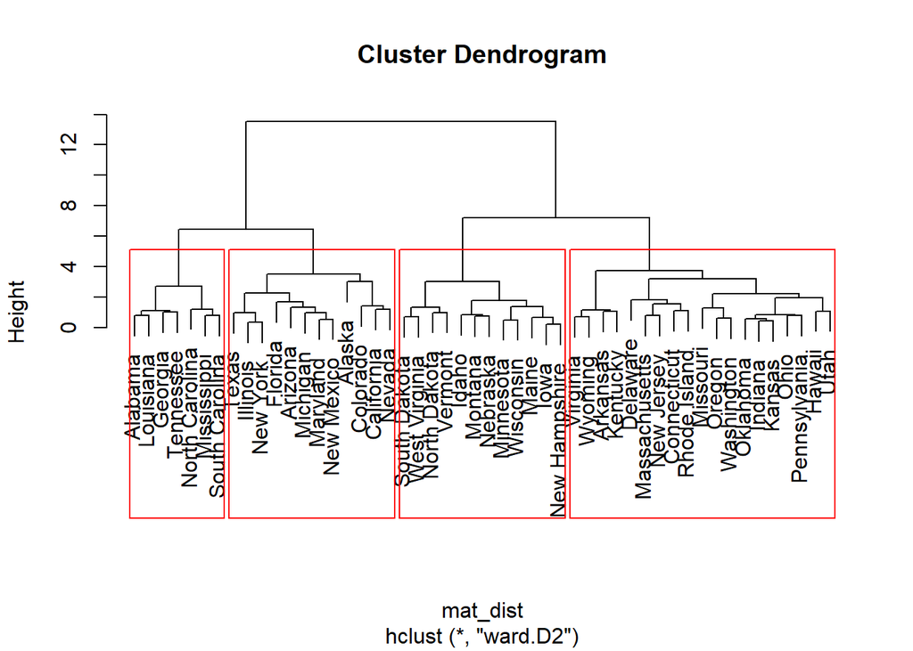

```r
plot(hc_ward )
rect.hclust(hc_ward, k=4, border="red")
```

```r
grupos<-cutree(hc_ward,k=3)
split(rownames(datos),grupos)
```

```
## $`1`
##  [1] "Alabama"        "Alaska"         "Arizona"        "California"
##  [5] "Colorado"       "Florida"        "Georgia"        "Illinois"
##  [9] "Louisiana"      "Maryland"       "Michigan"       "Mississippi"
## [13] "Nevada"         "New Mexico"     "New York"       "North Carolina"
## [17] "South Carolina" "Tennessee"      "Texas"
##
## $`2`
##  [1] "Arkansas"      "Connecticut"   "Delaware"      "Hawaii"
##  [5] "Indiana"       "Kansas"        "Kentucky"      "Massachusetts"
##  [9] "Missouri"      "New Jersey"    "Ohio"          "Oklahoma"
## [13] "Oregon"        "Pennsylvania"  "Rhode Island"  "Utah"
## [17] "Virginia"      "Washington"    "Wyoming"
##
## $`3`
##  [1] "Idaho"         "Iowa"          "Maine"         "Minnesota"
##  [5] "Montana"       "Nebraska"      "New Hampshire" "North Dakota"
##  [9] "South Dakota"  "Vermont"       "West Virginia" "Wisconsin"
```

#### Coeficiente de correlación cofenética

```r
cor(x = mat_dist, cophenetic(hc_complete))
```

```
## [1] 0.6979437
```

```r
cor(x = mat_dist, cophenetic(hc_average))
```

```
## [1] 0.7180382
```

```r
cor(x = mat_dist, cophenetic(hc_single))
```

```
## [1] 0.541272
```

```r
cor(x = mat_dist, cophenetic(hc_ward))
```

```
## [1] 0.6975266
```

#### **Clustering usando el paquete factoextra**

#### Dendrograma y representación gráfica de la segmentación en dos dimensiones

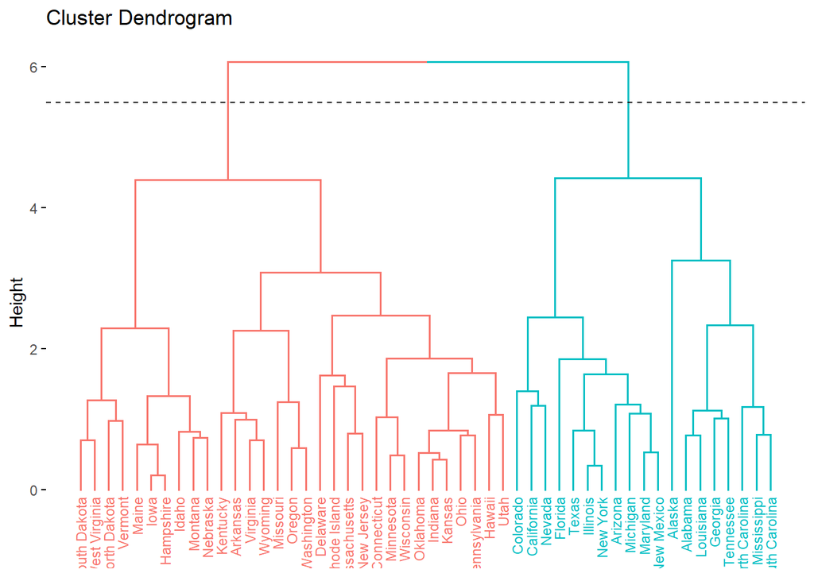

```r
datos2 <- USArrests
hc_completo <- datos2 %>% scale() %>% dist(method = "euclidean") %>%
  hclust(method = "complete")

fviz_dend(x = hc_completo, k = 2, cex = 0.6) +
  geom_hline(yintercept = 5.5, linetype = "dashed")
```

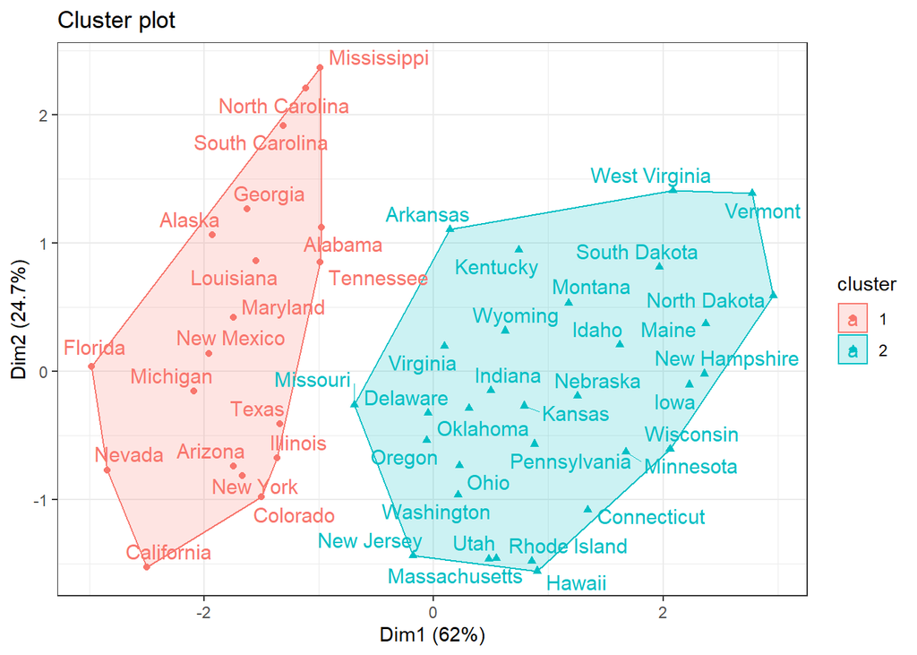

```r
fviz_cluster(object = list(data = datos2, cluster = cutree(hc_completo, k = 2)), ellipse.type = "convex", repel = TRUE, show.clust.cent = FALSE) +
  theme_bw()
```

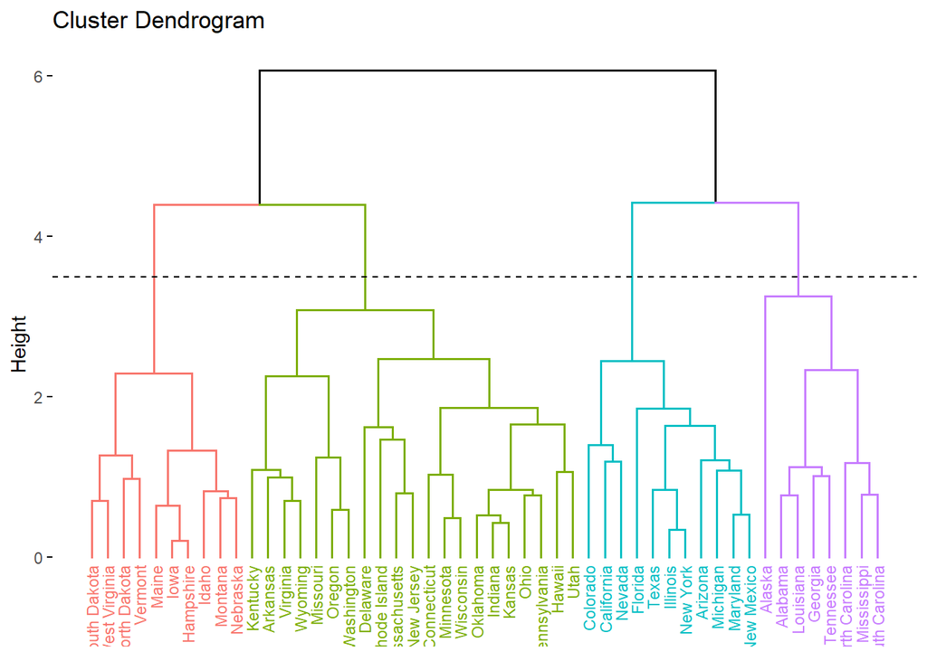

```r
fviz_dend(x = hc_completo, k = 4, cex = 0.6) +
  geom_hline(yintercept = 3.5, linetype = "dashed")
```

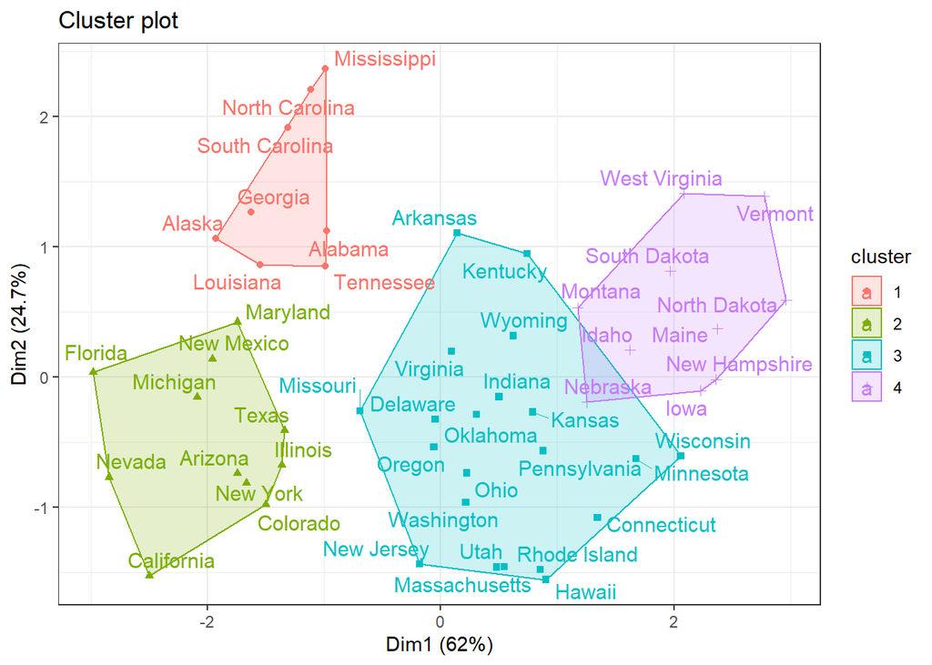

```r
fviz_cluster(object = list(data = datos2, cluster = cutree(hc_completo, k = 4)), ellipse.type = "convex", repel = TRUE, show.clust.cent = FALSE) +
  theme_bw()
```

#### Selección de número óptimo de clusters

**Método de Elbow**

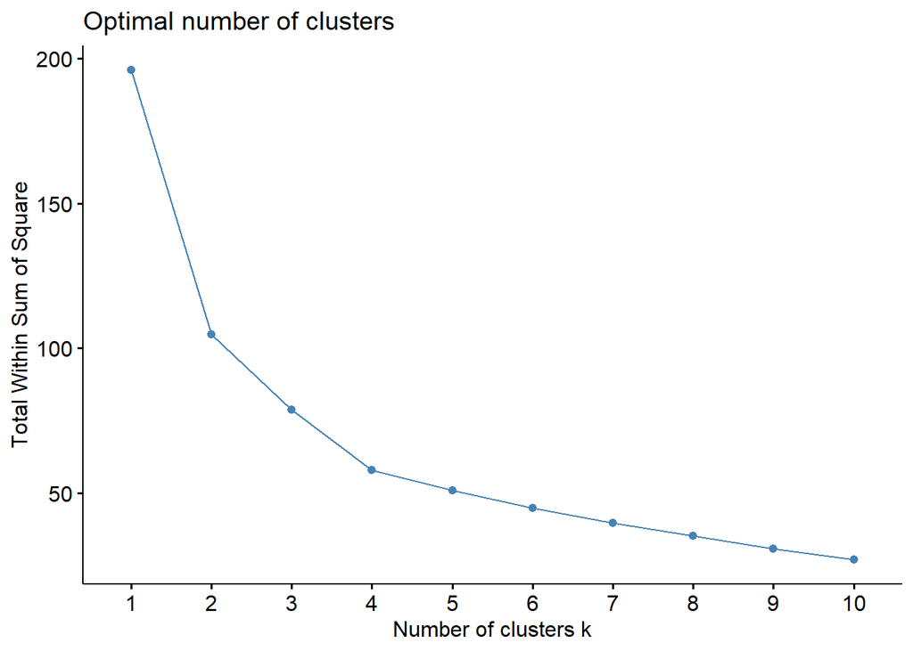

```r
fviz_nbclust(x = datos2, FUNcluster = hcut,hc_method ="ward.D2",stand=TRUE, method = "wss",
             diss = dist(datos, method = "euclidean"))
```

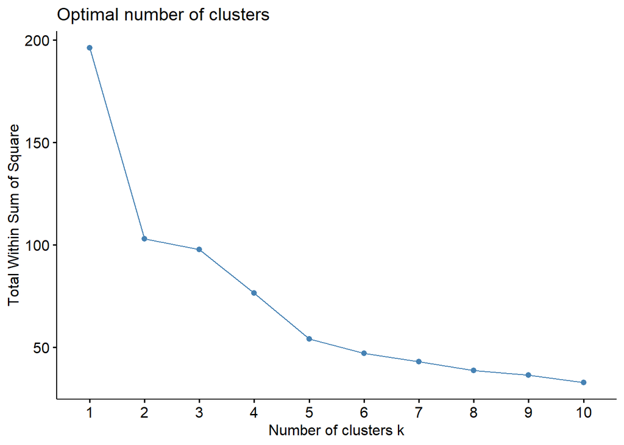

```r
fviz_nbclust(x = datos2, FUNcluster = hcut,hc_method ="average",stand=TRUE, method = "wss",
             diss = dist(datos, method = "euclidean"))
```

**Coeficiente silhouette**

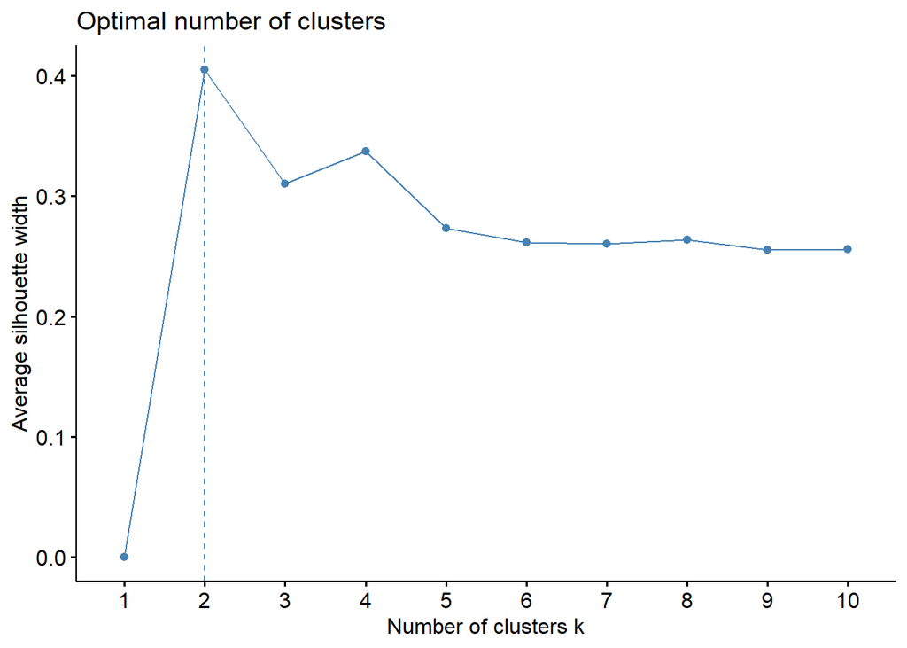

```r
fviz_nbclust(x = datos2, FUNcluster = hcut,hc_method ="ward.D2",stand=TRUE, method = "silhouette",
             diss = dist(datos, method = "euclidean"))
```

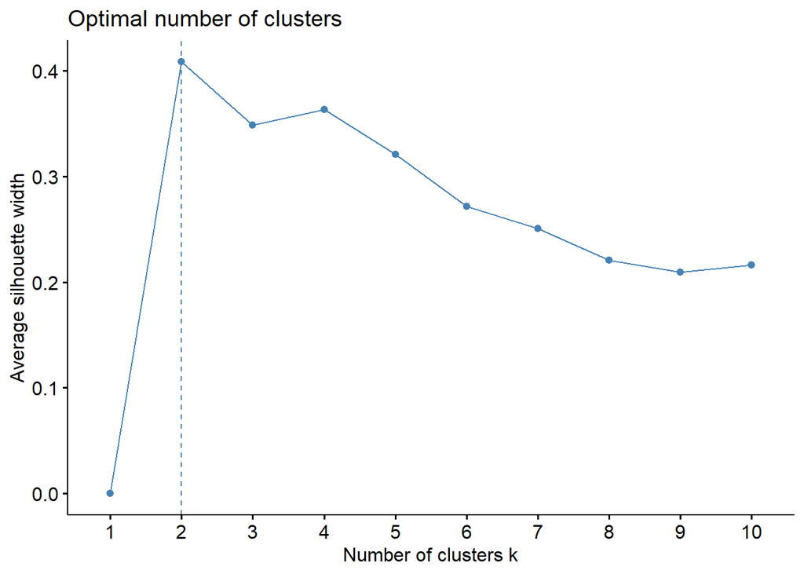

```r
fviz_nbclust(x = datos2, FUNcluster = hcut,hc_method ="average",stand=TRUE, method = "silhouette",
             diss = dist(datos, method = "euclidean"))
```

**Método del estadístico gap**

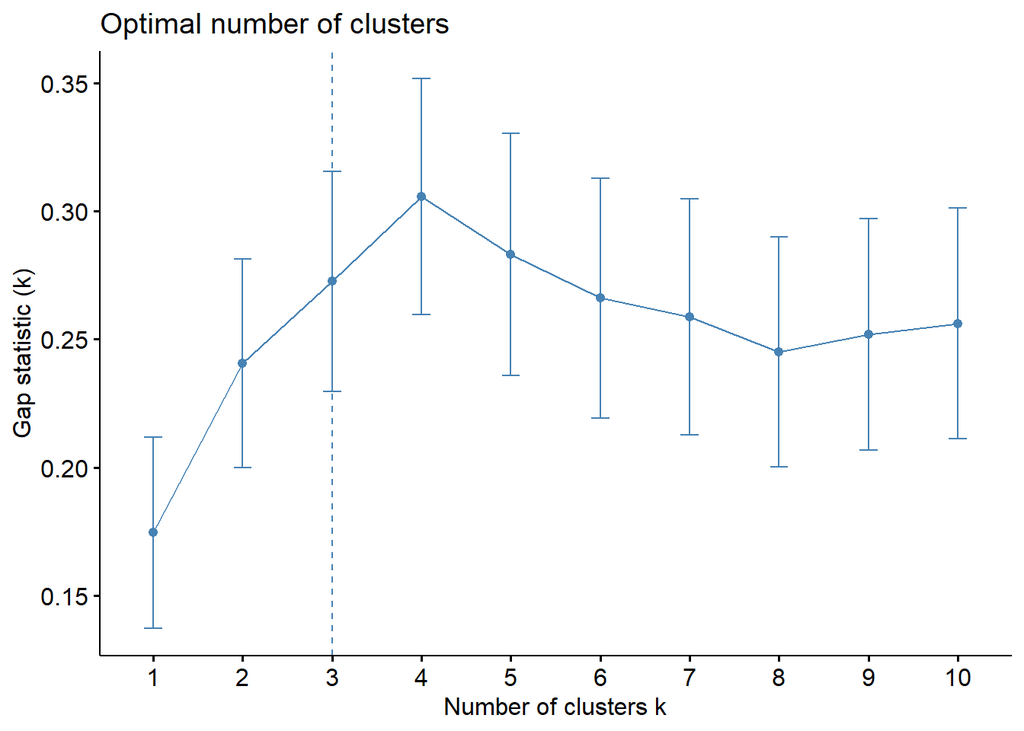

```r
fviz_nbclust(x = datos, FUNcluster = hcut,hc_method ="ward.D2", method = "gap_stat",
             diss = dist(datos, method = "euclidean"))
```

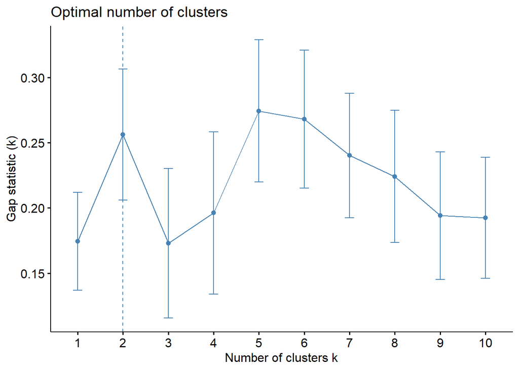

```r
fviz_nbclust(x = datos, FUNcluster = hcut,hc_method ="average", method = "gap_stat",
             diss = dist(datos, method = "euclidean"))
```

### K-means:

#### Selección de número óptimo de clusters

**Método de Elbow**

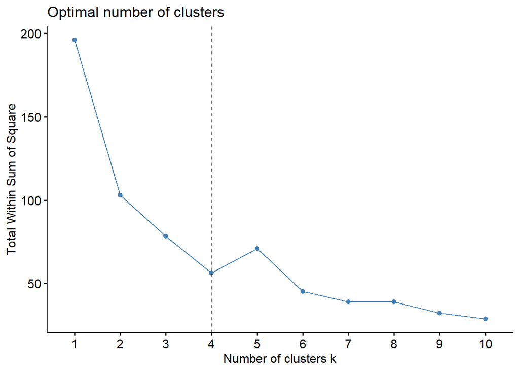

```r
fviz_nbclust(x = datos, FUNcluster = kmeans, method = "wss",
             diss = dist(datos, method = "euclidean")) +
  geom_vline(xintercept = 4, linetype = 2)
```

**Coeficiente silhouette**

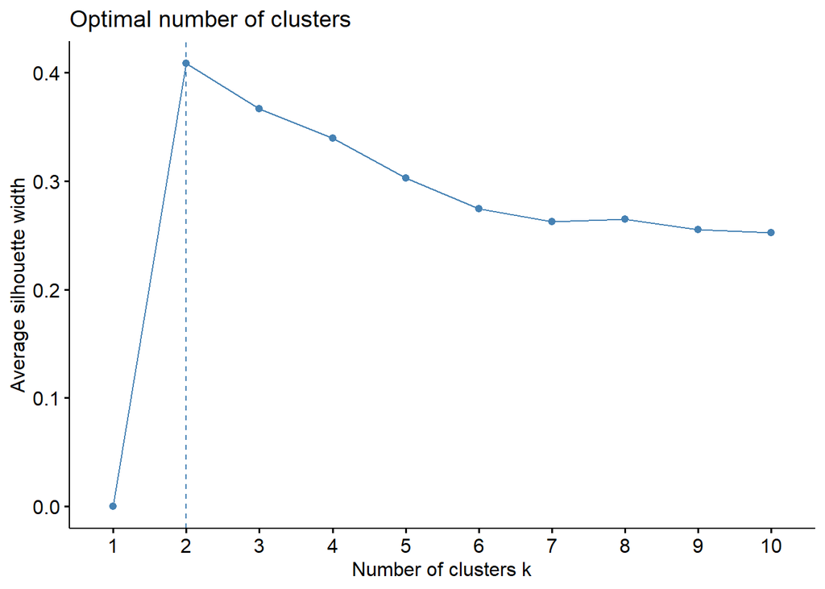

```r
fviz_nbclust(x = datos, FUNcluster = kmeans, method = "silhouette",
             diss = dist(datos, method = "euclidean"))
```

**Método del estadístico gap**

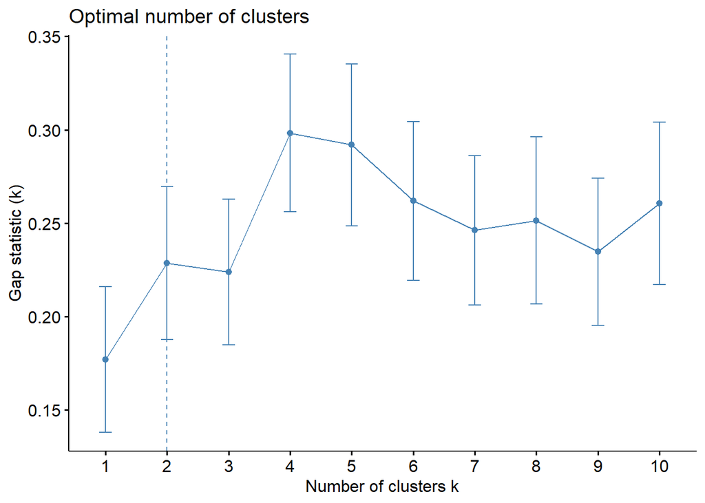

```r
fviz_nbclust(x = datos, FUNcluster = kmeans, method = "gap_stat",
             diss = dist(datos, method = "euclidean"))
```

#### Segmentación en 4 grupos

```r
set.seed(123)
km_clusters <- kmeans(x = datos, centers = 4, nstart = 25)
names(km_clusters)
```

```
## [1] "cluster"      "centers"      "totss"        "withinss"     "tot.withinss"
## [6] "betweenss"    "size"         "iter"         "ifault"
```

```r
split(rownames(datos),km_clusters$cluster)
```

```
## $`1`
## [1] "Alabama"        "Arkansas"       "Georgia"        "Louisiana"
## [5] "Mississippi"    "North Carolina" "South Carolina" "Tennessee"
##
## $`2`
##  [1] "Idaho"         "Iowa"          "Kentucky"      "Maine"
##  [5] "Minnesota"     "Montana"       "Nebraska"      "New Hampshire"
##  [9] "North Dakota"  "South Dakota"  "Vermont"       "West Virginia"
## [13] "Wisconsin"
##
## $`3`
##  [1] "Connecticut"   "Delaware"      "Hawaii"        "Indiana"
##  [5] "Kansas"        "Massachusetts" "New Jersey"    "Ohio"
##  [9] "Oklahoma"      "Oregon"        "Pennsylvania"  "Rhode Island"
## [13] "Utah"          "Virginia"      "Washington"    "Wyoming"
##
## $`4`
##  [1] "Alaska"     "Arizona"    "California" "Colorado"   "Florida"
##  [6] "Illinois"   "Maryland"   "Michigan"   "Missouri"   "Nevada"
## [11] "New Mexico" "New York"   "Texas"
```

#### Representación gráfica de la segmentación en dos dimensiones

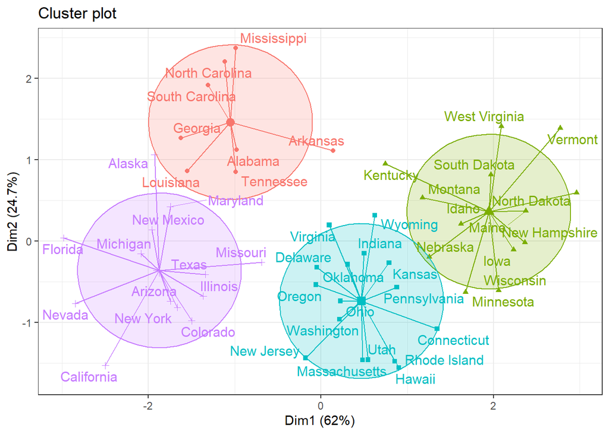

```r
fviz_cluster(object = km_clusters, data = datos, show.clust.cent = TRUE, ellipse.type = "euclid", star.plot = TRUE, repel = TRUE) +
  theme_bw() +
  theme(legend.position = "none")
```

### Ejemplo con variables categóricas

Utilizamos el dataset provisto por R de hongos clasificados como comestibles y venenosos (o no recomendables para consumo). La idea es ver si es posible separar ambos grupos obviamente sin valernos de la columna de la clase, y en ese caso entender qué características diferencian ambos segmentos.

```r
library(cba)
library(vegan)
data("Mushroom")
head(Mushroom)
```

|  | class | cap-shape | cap-surface | cap-color | bruises? | odor | gill-attachment | gill-spacing | gill-size | gill-color | stalk-shape | stalk-root | stalk-surface-above-ring | stalk-surface-below-ring | stalk-color-above-ring | stalk-color-below-ring | veil-type | veil-color | ring-number | ring-type | spore-print-color | population | habitat |
| --- | --- | --- | --- | --- | --- | --- | --- | --- | --- | --- | --- | --- | --- | --- | --- | --- | --- | --- | --- | --- | --- | --- | --- |
| 1 | poisonous | convex | smooth | brown | bruises | pungent | free | close | narrow | black | enlarging | equal | smooth | smooth | white | white | partial | white | one | pendant | black | scattered | urban |
| 2 | edible | convex | smooth | yellow | bruises | almond | free | close | broad | black | enlarging | club | smooth | smooth | white | white | partial | white | one | pendant | brown | numerous | grasses |
| 3 | edible | bell | smooth | white | bruises | anise | free | close | broad | brown | enlarging | club | smooth | smooth | white | white | partial | white | one | pendant | brown | numerous | meadows |
| 4 | poisonous | convex | scaly | white | bruises | pungent | free | close | narrow | brown | enlarging | equal | smooth | smooth | white | white | partial | white | one | pendant | black | scattered | urban |
| 5 | edible | convex | smooth | gray | no | none | free | crowded | broad | black | tapering | equal | smooth | smooth | white | white | partial | white | one | evanescent | brown | abundant | grasses |
| 6 | edible | convex | scaly | yellow | bruises | almond | free | close | broad | brown | enlarging | club | smooth | smooth | white | white | partial | white | one | pendant | black | numerous | grasses |

```r
dim(Mushroom)
```

```
## [1] 8124   23
```

```r
colnames(Mushroom)
```

```
##  [1] "class"                    "cap-shape"
##  [3] "cap-surface"              "cap-color"
##  [5] "bruises?"                 "odor"
##  [7] "gill-attachment"          "gill-spacing"
##  [9] "gill-size"                "gill-color"
## [11] "stalk-shape"              "stalk-root"
## [13] "stalk-surface-above-ring" "stalk-surface-below-ring"
## [15] "stalk-color-above-ring"   "stalk-color-below-ring"
## [17] "veil-type"                "veil-color"
## [19] "ring-number"              "ring-type"
## [21] "spore-print-color"        "population"
## [23] "habitat"
```

Para simplificar el análisis, seleccionamos algunas variables de interés, ya que al aplicar el comando dummy se multiplican las variables del dataset binario.

```r
mush<-Mushroom[,c(1:6,19:23)]
summary(mush)
```

```
##        class        cap-shape     cap-surface     cap-color       bruises?
##  edible   :4208   bell   : 452   fibrous:2320   brown  :2284   bruises:3376
##  poisonous:3916   conical:   4   grooves:   4   gray   :1840   no     :4748
##                   convex :3656   scaly  :3244   red    :1500
##                   flat   :3152   smooth :2556   yellow :1072
##                   knobbed: 828                  white  :1040
##                   sunken :  32                  buff   : 168
##                                                 (Other): 220
##       odor      ring-number      ring-type    spore-print-color
##  none   :3528   none:  36   evanescent:2776   white    :2388
##  foul   :2160   one :7488   flaring   :  48   brown    :1968
##  fishy  : 576   two : 600   large     :1296   black    :1872
##  spicy  : 576               none      :  36   chocolate:1632
##  almond : 400               pendant   :3968   green    :  72
##  anise  : 400                                 buff     :  48
##  (Other): 484                                 (Other)  : 144
##      population      habitat
##  abundant : 384   grasses:2148
##  clustered: 340   leaves : 832
##  numerous : 400   meadows: 292
##  scattered:1248   paths  :1144
##  several  :4040   urban  : 368
##  solitary :1712   waste  : 192
##                   woods  :3148
```

```r
xx <- as.dummy(mush[-1])
dim(xx)
```

```
## [1] 8124   61
```

```r
head(xx)
```

```
##   cap-shape bell cap-shape conical cap-shape convex cap-shape flat
## 1          FALSE             FALSE             TRUE          FALSE
## 2          FALSE             FALSE             TRUE          FALSE
## 3           TRUE             FALSE            FALSE          FALSE
## 4          FALSE             FALSE             TRUE          FALSE
## 5          FALSE             FALSE             TRUE          FALSE
## 6          FALSE             FALSE             TRUE          FALSE
##   cap-shape knobbed cap-shape sunken cap-surface fibrous cap-surface grooves
## 1             FALSE            FALSE               FALSE               FALSE
## 2             FALSE            FALSE               FALSE               FALSE
## 3             FALSE            FALSE               FALSE               FALSE
## 4             FALSE            FALSE               FALSE               FALSE
## 5             FALSE            FALSE               FALSE               FALSE
## 6             FALSE            FALSE               FALSE               FALSE
##   cap-surface scaly cap-surface smooth cap-color brown cap-color buff
```

[output cut: 90 more lines]

Notar que en este caso, al tratarse de variables categóricas vamos a binarizar las variables, para luego utilizar la distancia de Jaccard, muy últil para datos donde las columnas representan la ausencia o presencia de una determinada característica. Es por esto que no se requiere ningún tipo de normalización posterior.

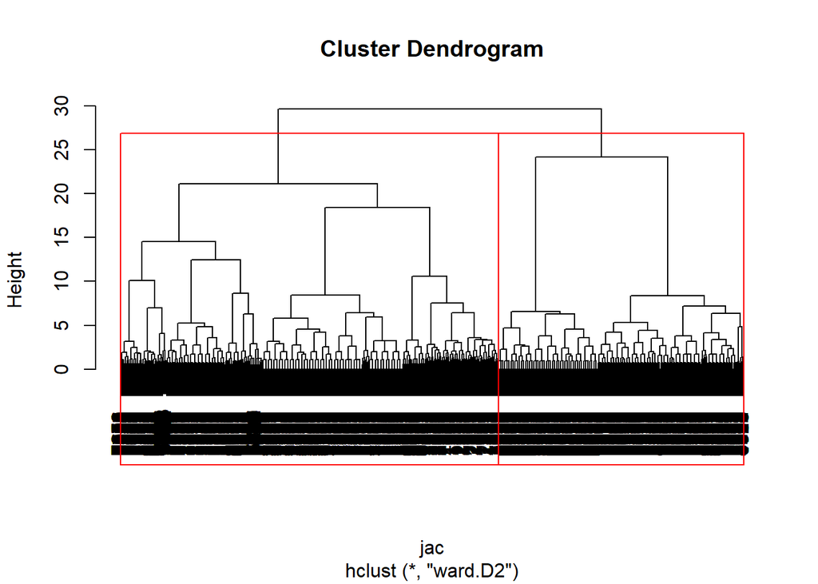

```r
jac<-vegdist(xx, method = "jaccard")
hc_ward <- hclust(d = jac, method = "ward.D2")
plot(hc_ward)
rect.hclust(hc_ward, k=2, border="red")
```

Calculamos las proporciones de comestibles y venenosos en cada grupo a modo de validación, pero la idea es que justamente, en los problemas de clustering no hay una variable de clase, sino que se intenta a partir de otras características entender si es posible separar en grupos diferentes. Luego, de acuerdo a esas caracteísticas y si se observan diferencias claras, se puede definir una etiqueta de clase. Acá estamos haciendo trampa, pero es para ver que la metodología separa correctamente en dos segmentos.

```r
grupos<-cutree(hc_ward,k=2)
gr<-split(mush[1],grupos)
table(gr[[1]])
```

```
## class
##    edible poisonous
##      4112       816
```

```r
table(gr[[2]])
```

```
## class
##    edible poisonous
##        96      3100
```

Analizamos las características de cada grupo para determinar dónde se observa la mayoría de las diferencias.

```r
sp<-split(mush,grupos)
edi<-sp[[1]]
poi<-sp[[2]]
summary(edi)
```

```
##        class        cap-shape     cap-surface     cap-color       bruises?
##  edible   :4112   bell   : 442   fibrous:1632   brown  :1368   bruises:3376
##  poisonous: 816   conical:   2   grooves:   4   gray   :1192   no     :1552
##                   convex :2372   scaly  :1600   white  :1024
##                   flat   :1866   smooth :1692   red    : 624
##                   knobbed: 214                  yellow : 400
##                   sunken :  32                  buff   : 168
##                                                 (Other): 152
##        odor      ring-number      ring-type    spore-print-color
##  none    :3392   none:   0   evanescent: 960   brown    :1968
##  almond  : 400   one :4328   flaring   :   0   black    :1872
##  anise   : 400   two : 600   large     :   0   white    : 536
##  foul    : 288               none      :   0   chocolate: 288
##  pungent : 256               pendant   :3968   green    :  72
##  creosote: 192                                 buff     :  48
##  (Other) :   0                                 (Other)  : 144
##      population      habitat
##  abundant : 384   grasses:1716
##  clustered: 296   leaves : 200
##  numerous : 400   meadows: 292
##  scattered:1248   paths  : 136
##  several  :1560   urban  : 368
##  solitary :1040   waste  : 192
##                   woods  :2024
```

```r
summary(poi)
```

```
##        class        cap-shape     cap-surface      cap-color      bruises?
##  edible   :  96   bell   :  10   fibrous: 688   brown   :916   bruises:   0
##  poisonous:3100   conical:   2   grooves:   0   red     :876   no     :3196
##                   convex :1284   scaly  :1644   yellow  :672
##                   flat   :1286   smooth : 864   gray    :648
##                   knobbed: 614                  cinnamon: 36
##                   sunken :   0                  green   : 16
##                                                 (Other) : 32
##       odor      ring-number      ring-type    spore-print-color
##  foul   :1872   none:  36   evanescent:1816   white    :1852
##  fishy  : 576   one :3160   flaring   :  48   chocolate:1344
##  spicy  : 576   two :   0   large     :1296   black    :   0
##  none   : 136               none      :  36   brown    :   0
##  musty  :  36               pendant   :   0   buff     :   0
##  almond :   0                                 green    :   0
##  (Other):   0                                 (Other)  :   0
##      population      habitat
##  abundant :   0   grasses: 432
##  clustered:  44   leaves : 632
##  numerous :   0   meadows:   0
##  scattered:   0   paths  :1008
##  several  :2480   urban  :   0
##  solitary : 672   waste  :   0
##                   woods  :1124
```